Date: 20th February,2018

Assignment: WSMA

Name: ANAND ROY

FT NUMBER: FT183014

Topic:Sentiment Analysis on ‘#bse’

## Frequency of most commonly used terms in the tweets

```r
memory.limit(10000)
```

```
## [1] 10000
```

```r
#Check R version
#R.version
#Load Library
library(SnowballC)
library(tm)
```

```r
library(ggplot2)
library(RColorBrewer)
library(wordcloud)
library(topicmodels)
library(data.table)
library(stringi)
library(dplyr)
library(syuzhet)
library(plyr)
library(grid)
library(gridExtra)
#Set Path
setwd("C:\\Users\\Administrator\\Desktop")
#Connect to twitter
require(twitteR)
require(RCurl)
consumer_key <- 'qphOKHTyzytPVVcaex4BrZ4ZO'
consumer_secret <- 'SitJMkcLnLUEvirvGtYPsuD5kgdWqFZ4EerLVJSThxc7CRkJrC'
access_token <- '161544752-HHH6j4MKpk5SVRYQ5POHRLPFUfUbMHjhMhYAQOL7'
access_secret <- 'Okd9rQoRWmetiGK0D338NMaFJnvuL96hLSG5qRfulvZOu'
setup_twitter_oauth(consumer_key,consumer_secret,access_token,access_secret)
```

```
## [1] "Using direct authentication"
```

```r
data_bse <- searchTwitter("#bse",n=2500,since = "2012-01-01", lang="en")
length.df_bse <- length(data_bse)
length.df_bse
```

```
## [1] 978
```

```r
data_bse.df<-ldply(data_bse,function(t) t$toDataFrame())

#Formatting
#Formatting date

data_bse.df$created<-as.Date(data_bse.df$created)

#Formatting text
d_text = sapply(data_bse,function(x)x$getText())
#Remove people name
d_text1 <- gsub("@[^[:space:]]*", "", d_text)
#Remove HTML
d_text2 <-  gsub("http[^[:space:]]*", "", d_text1)
#Remove Anything except English Language and Space
d_text3 <- gsub("[^[:alpha:][:space:]]*", "", d_text2)
#Some more data cleaning
d_text4 <- gsub("RT","",d_text3)
d_text5 <- gsub("\n","",d_text4)


#write to csv
data=data.table("Tweet"= d_text5, "created" = data_bse.df$created)
write.csv(data,"bse_tweets.csv")

#Load excel file
tweets.df <- read.csv("bse_tweets.csv")
names(tweets.df)
```

```
## [1] "X"       "Tweet"   "created"
```

```r
str(tweets.df)
```

```
## 'data.frame':    978 obs. of  3 variables:
##  $ X      : int  1 2 3 4 5 6 7 8 9 10 ...
##  $ Tweet  : Factor w/ 829 levels "          ","      Here comes the deglobalisation of Indian fi ",..: 823 353 759 711 81 582 583 253 243 207 ...
##  $ created: Factor w/ 11 levels "2018-02-10","2018-02-11",..: 11 11 11 11 11 11 11 11 11 11 ...
```

```r
tweets.df$Tweet <- as.character(tweets.df$Tweet)
tweets.df$X = NULL
#Data Cleanising
#Build Corpus
myCorpus<- Corpus(VectorSource(tweets.df$Tweet))
#convert to LowerCase
myCorpus <- tm_map(myCorpus,tolower)
#remove stopwords
myCorpus <- tm_map(myCorpus,removeWords, c(stopwords("english"),"kickoutcancer","stocks","stockmarket","bcanawareness","thakur","shri","going","ajay","spselva","amp","rose","cueswe","madampceo","cancerawareness","breast","breastcancer","see","fut","providing","just","feb","find","get","fut","bourses","bse","can","one","comes","mdampceo","take","face","dewan","cro","shasun","guys"))
#remove numbers
myCorpus <- tm_map(myCorpus,removeNumbers)
#remove Punctuation
myCorpus <- tm_map(myCorpus,removePunctuation)
#remove whitespace
myCorpus <- tm_map(myCorpus,stripWhitespace)
myCorpusCopy<- myCorpus
#find most frequent term
dtm <- TermDocumentMatrix(myCorpus)
(freq.terms <- findFreqTerms(dtm, lowfreq = 30))
```

```
##  [1] "nifty"         "nse"           "india"         "trading"
##  [5] "sensex"        "good"          "will"          "niftyfuture"
##  [9] "target"        "stock"         "stockstowatch" "shares"
## [13] "tips"          "buy"           "indian"        "market"
## [17] "markets"       "news"          "term"          "now"
## [21] "trade"         "pnb"           "points"        "day"
## [25] "equity"        "nasdaq"        "investment"    "share"
```

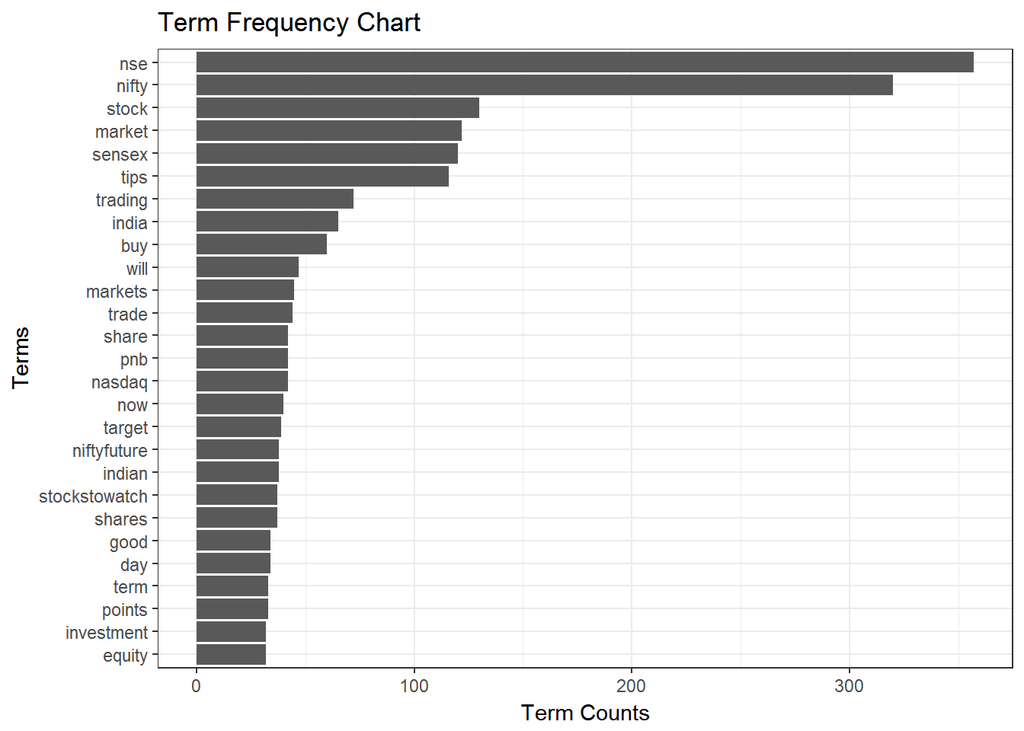

```r
term.freq <- rowSums(as.matrix(dtm))
term.freq <- subset(term.freq, term.freq > 30)
df <- data.frame(term = names(term.freq), freq= term.freq)

#Plotting frequency of most used term
ggplot(df, aes(reorder(term, freq),freq)) + theme_bw() + geom_bar(stat = "identity")  + coord_flip() +labs(list(title="Term Frequency Chart", x="Terms", y="Term Counts"))
```

From th term frequency Chart, we observe ‘nse’/‘nifty’ having the highest frequency of occurance in tweets followed by stock, market,sensex and tips. BSE index is highly related with NSE, which is verified from the data. Also traders, trading in BSE frequently look for stock tips rather than indepth fundamental & technical analysis.

## WordCloud

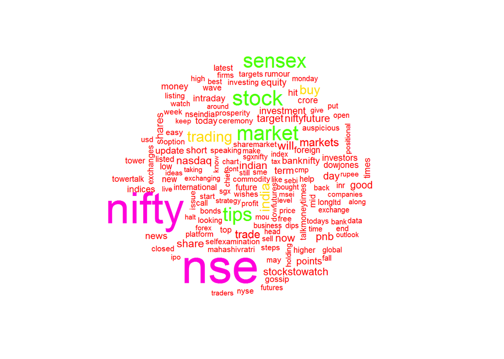

```r
#plotting the word cloud
dtm <- DocumentTermMatrix(myCorpus)
m <- as.matrix(dtm)
v <- sort(colSums(m),decreasing=TRUE)
words <- names(v)
d <- data.frame(word=words, freq=v)
wordcloud(d$word,d$freq,min.freq=10, colors=rainbow(7))
```

Again, we see that Tips are amongst the most sought after keywords in the tweets suggesting that traders do rely on stock tips. Also NASDAQ(USA market) is closely observed by BSE traders. PNB being the latest scam is the only significant company name that came out.

## Association with specific keywords in the tweets

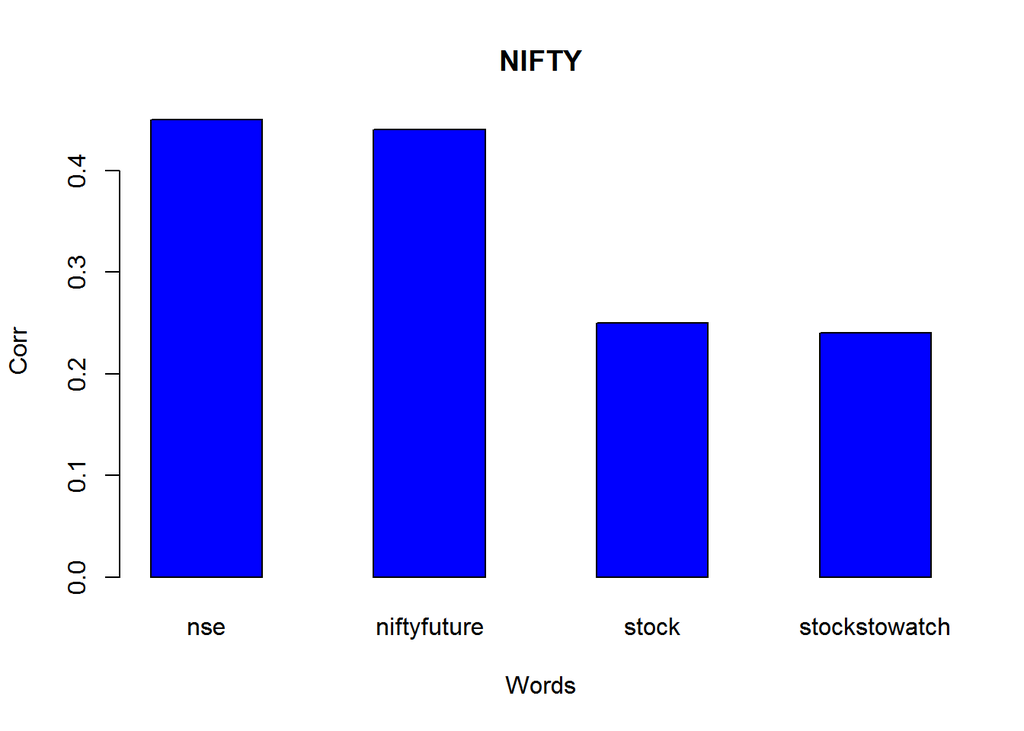

```r
#Find association with a specific keyword in the tweets

list1<- findAssocs(dtm, "nifty", 0.21)
corrdf1 <- t(data.frame(t(sapply(list1,c))))
#corrdf1

list2<- findAssocs(dtm,"nse",0.2)
corrdf2 <- t(data.frame(t(sapply(list2,c))))
#corrdf2

list3<- findAssocs(dtm,"market",0.23)
corrdf3 <- t(data.frame(t(sapply(list3,c))))
#corrdf3

#list4<- findAssocs(dtm,"inr",0.33)
#corrdf4 <- t(data.frame(t(sapply(list4,c))))
#corrdf4

#list5<- findAssocs(dtm,"bank",0.2)
#corrdf5 <- t(data.frame(t(sapply(list5,c))))
#corrdf5

list6<- findAssocs(dtm,"nasdaq",0.24)
corrdf6 <- t(data.frame(t(sapply(list6,c))))
#corrdf6

list7<- findAssocs(dtm,"tips",0.2)
corrdf7 <- t(data.frame(t(sapply(list7,c))))
#corrdf7

list8<- findAssocs(dtm,"pnb",0.26)
corrdf8 <- t(data.frame(t(sapply(list8,c))))
#corrdf8

#Barplot
barplot(t(as.matrix(corrdf1)),beside=TRUE,xlab = "Words",ylab = "Corr",col = "blue",main = "NIFTY",border = "black")
```

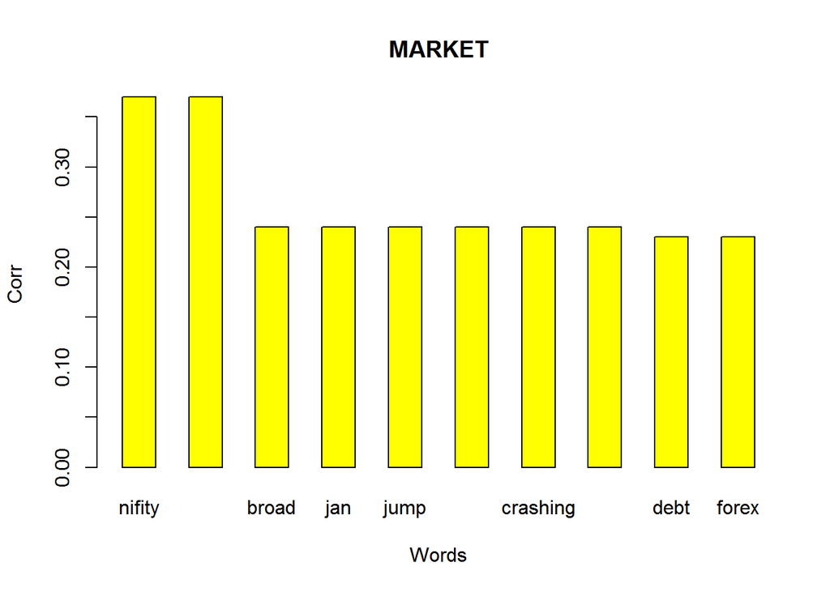

```r
barplot(t(as.matrix(corrdf3)),beside=TRUE,xlab = "Words",ylab = "Corr",col = "yellow",main = "MARKET",border = "black")
```

BSE is the biggest Indian stock market where apart from BSE NIFTY & the debt market are also heavily discussed.

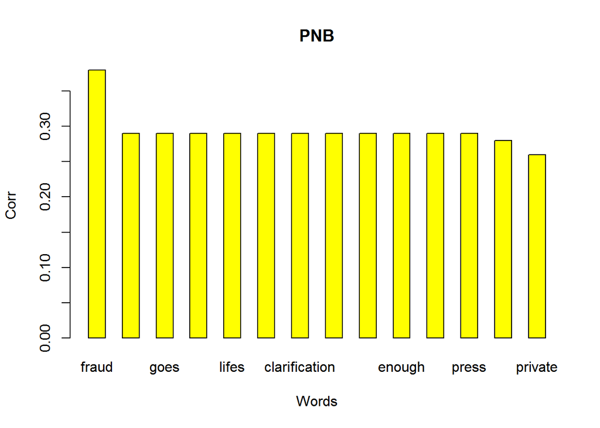

```r
barplot(t(as.matrix(corrdf8)),beside=TRUE,xlab = "Words",ylab = "Corr",col = "yellow",main = "PNB",border = "black")
```

Because of the recent scam,fraud is the most correlated term with PNB. People have tweeted about the conferences and blamed the management.

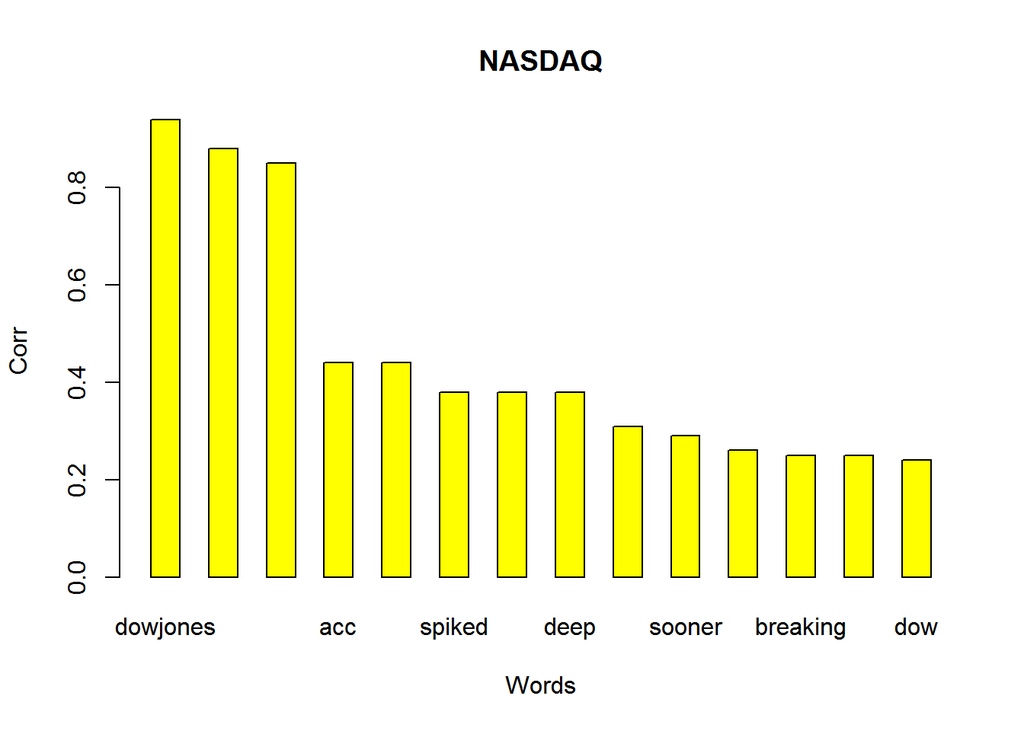

```r
barplot(t(as.matrix(corrdf6)),beside=TRUE,xlab = "Words",ylab = "Corr",col = "yellow",main = "NASDAQ",border = "black")
```

Just like BSE and NSE, NASDAQ & DOW JONES are the most correletad terms suggetsing that markets of same country are mostly twieeted/discussed together. Apparently, USDJPY(US $ and Japanese Yen) is discussed alongwith NASDAQ.

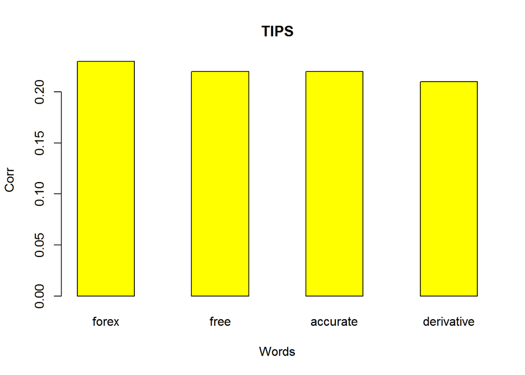

```r
barplot(t(as.matrix(corrdf7)),beside=TRUE,xlab = "Words",ylab = "Corr",col = "yellow",main = "TIPS",border = "black")
```

Since most of the BSE traders were discussing about tips, we explored about the terms that are highly correlated with tips. We see that FOREX and Derivative market tips are mostly tweeted.Also people are looking for free tips.

## Topic Modelling

```r
#Topic Modelling to identify latent/hidden topics using LDA technique
tdm <- as.DocumentTermMatrix(dtm)
rowTotals <- apply(tdm , 1, sum)
NullDocs <- tdm[rowTotals==0, ]
tdm   <- tdm[rowTotals> 0, ]

if (length(NullDocs$dimnames$Docs) > 0) {
  tweets.df <- tweets.df[-as.numeric(NullDocs$dimnames$Docs),]
}

lda <- LDA(tdm, k = 5) # find 5 topic
term <- terms(lda, 7) # first 7 terms of every topic
(term <- apply(term, MARGIN = 2, paste, collapse = ", "))
```

```
##                                                 Topic 1
##         "nse, sensex, market, tips, now, nasdaq, nifty"
##                                                 Topic 2
##      "nifty, nse, india, market, stock, trading, share"
##                                                 Topic 3
##   "stock, nifty, nse, sensex, stockstowatch, tips, buy"
##                                                 Topic 4
##             "nse, nifty, sensex, tips, stock, day, buy"
##                                                 Topic 5
## "nse, market, nifty, tips, markets, niftyfuture, stock"
```

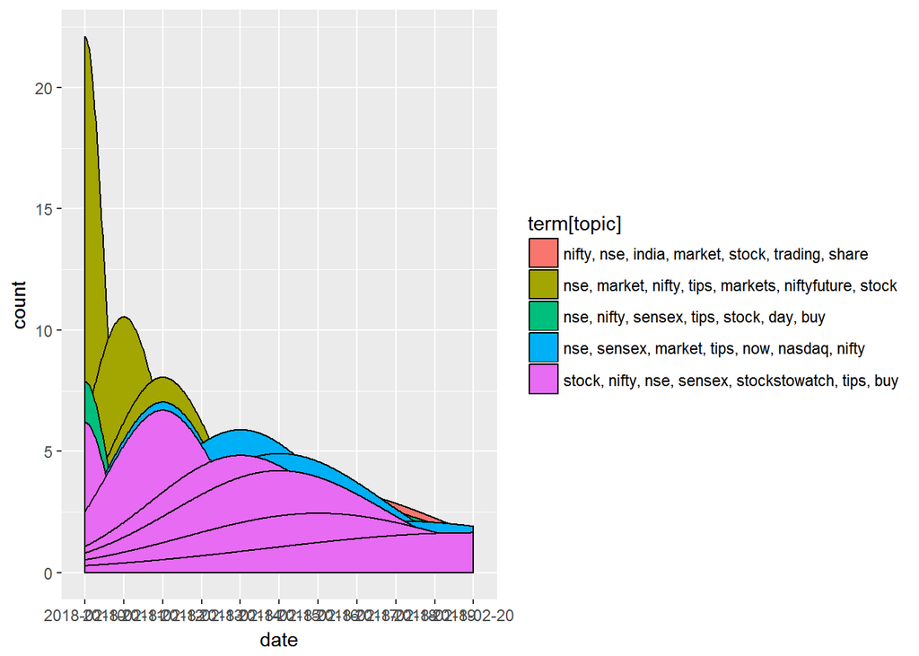

```r
topics<- topics(lda)
topics<- data.frame(date=(tweets.df$created), topic = topics)
qplot (date, ..count.., data=topics, geom ="density", fill= term[topic], position="stack")
```

## Sentiment Analysis

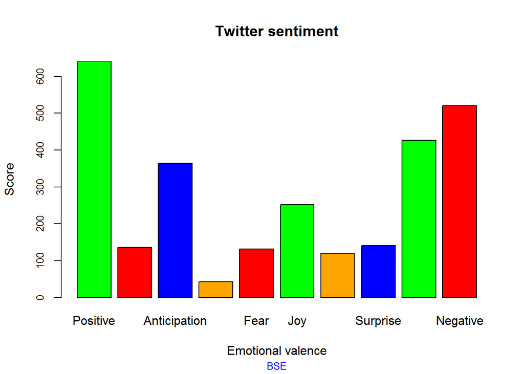

```r
#Sentiment Analysis: understanding emotional valence in tweets using syuzhet
mysentiment<-get_nrc_sentiment((tweets.df$Tweet))
mysentiment.positive =sum(mysentiment$positive)
mysentiment.anger =sum(mysentiment$anger)
mysentiment.anticipation =sum(mysentiment$anticipation)
mysentiment.disgust =sum(mysentiment$disgust)
mysentiment.fear =sum(mysentiment$fear)
mysentiment.joy =sum(mysentiment$joy)
mysentiment.sadness =sum(mysentiment$sadness)
mysentiment.surprise =sum(mysentiment$surprise)
mysentiment.trust =sum(mysentiment$trust)
mysentiment.negative =sum(mysentiment$negative)
yAxis <- c(mysentiment.positive,
           + mysentiment.anger,
           + mysentiment.anticipation,
           + mysentiment.disgust,
           + mysentiment.fear,
           + mysentiment.joy,
           + mysentiment.sadness,
           + mysentiment.surprise,
           + mysentiment.trust,
           + mysentiment.negative)
xAxis <- c("Positive","Anger","Anticipation","Disgust","Fear","Joy","Sadness",
           "Surprise","Trust","Negative")
colors <- c("green","red","blue","orange","red","green","orange","blue","green","red")
yRange <- range(0,yAxis)
barplot(yAxis, names.arg = xAxis,
        xlab = "Emotional valence", ylab = "Score", main = "Twitter sentiment",
        sub = "BSE", col = colors, border = "black", xpd = F, ylim = yRange,
        axisnames = T, cex.axis = 0.8, cex.sub = 0.8, col.sub = "blue")
```

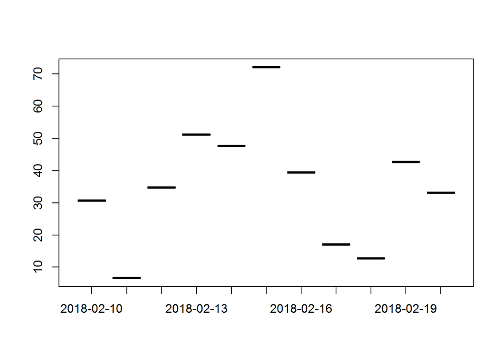

```r
mysentimentvalues <- data.frame(get_sentiment((tweets.df$Tweet)))
colnames(mysentimentvalues)<-"polarity"
mysentimentvalues$date <- tweets.df$created
result <- aggregate(polarity ~ date, data = mysentimentvalues, sum)
plot(result$date,result$polarity,order(result$date),type='l')
```

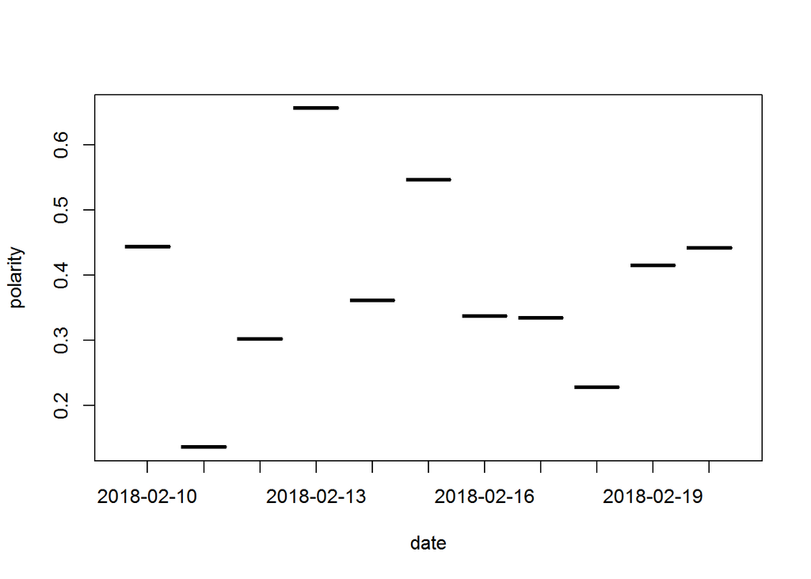

```r
result1 <- aggregate(polarity ~ date, data = mysentimentvalues, mean)
plot(result1, type = "l")
```